# Cour18

### Cours18 et 20 novembre 2017

```r
prof = read.table(file="prof.txt" , header = TRUE)
prof
```

| Sexe | DatEnt | Dep | SalEnt | Sal01 | Exp | Anc |
| --- | --- | --- | --- | --- | --- | --- |
| 0 | 1985 | CM | 10374 | 42683 | 22 | 16 |
| 1 | 1974 | CM | 5866 | 52439 | 27 | 27 |
| 0 | 1998 | PH | 21529 | 31707 | 22 | 3 |
| 1 | 1980 | SB | 9976 | 62317 | 30 | 21 |
| 1 | 1989 | CM | 14633 | 60000 | 20 | 12 |
| 1 | 1985 | CM | 12399 | 54756 | 28 | 16 |
| 1 | 1997 | IN | 21588 | 41951 | 21 | 4 |
| 0 | 1991 | CO | 19248 | 49512 | 48 | 10 |
| 1 | 1994 | PH | 12954 | 42927 | 22 | 7 |
| 1 | 1980 | IN | 8149 | 49512 | 28 | 21 |
| 1 | 1997 | CM | 18753 | 35854 | 21 | 4 |
| 1 | 1982 | MS | 9538 | 53415 | 22 | 19 |
| 1 | 1994 | MS | 19767 | 44878 | 23 | 7 |
| 1 | 1974 | MS | 6509 | 60000 | 26 | 27 |
| 1 | 1994 | CM | 19954 | 36829 | 33 | 7 |
| 1 | 1979 | IN | 7621 | 57927 | 22 | 22 |
| 1 | 1980 | SA | 8142 | 55854 | 27 | 21 |
| 1 | 1979 | CM | 10871 | 57073 | 22 | 22 |
| 0 | 1980 | CO | 9215 | 52683 | 18 | 21 |
| 1 | 2001 | SB | 26630 | 29878 | 21 | 0 |
| 0 | 1995 | SB | 22772 | 41585 | 27 | 6 |
| 0 | 2001 | MS | 30574 | 36098 | 39 | 0 |
| 1 | 1974 | MS | 7036 | 62195 | 30 | 27 |
| 1 | 1974 | PH | 6384 | 58049 | 32 | 27 |
| 1 | 1980 | IN | 6404 | 55976 | 17 | 21 |
| 1 | 1973 | CM | 6201 | 62805 | 34 | 28 |
| 0 | 1988 | CM | 12890 | 44268 | 30 | 13 |
| 0 | 1997 | MS | 24502 | 33659 | 28 | 4 |
| 1 | 1977 | PH | 8388 | 57073 | 43 | 24 |
| 1 | 1976 | CM | 5998 | 58049 | 22 | 25 |
| ⋮ | ⋮ | ⋮ | ⋮ | ⋮ | ⋮ | ⋮ |
| 1 | 1994 | PH | 11487 | 32561 | 21 | 7 |
| 0 | 1989 | SB | 16182 | 39775 | 26 | 12 |
| 0 | 1992 | PH | 13209 | 36929 | 21 | 9 |
| 0 | 1991 | PH | 17020 | 38352 | 23 | 10 |
| 0 | 2001 | SA | 29673 | 28390 | 41 | 0 |
| 0 | 1971 | PH | 4680 | 56851 | 24 | 30 |
| 0 | 2000 | MS | 27451 | 29814 | 27 | 1 |
| 0 | 1992 | MS | 16125 | 36929 | 31 | 9 |
| 0 | 1985 | CB | 13346 | 44044 | 33 | 16 |
| 0 | 1989 | MS | 13196 | 39775 | 27 | 12 |
| 0 | 1974 | IN | 7149 | 54005 | 33 | 27 |
| 0 | 1997 | CB | 18673 | 32660 | 20 | 4 |
| 0 | 1988 | SB | 12819 | 41198 | 20 | 13 |
| 0 | 1983 | PH | 9358 | 45467 | 31 | 18 |
| 0 | 1995 | CO | 17522 | 34083 | 22 | 6 |
| 0 | 1977 | SA | 7781 | 51159 | 35 | 24 |
| 1 | 1994 | PH | 20335 | 35506 | 32 | 7 |
| 1 | 1979 | CO | 8709 | 49736 | 29 | 22 |
| 1 | 1977 | SA | 7049 | 51159 | 31 | 24 |
| 1 | 2001 | IN | 31643 | 28390 | 37 | 0 |
| 1 | 1983 | SB | 9908 | 45467 | 29 | 18 |
| 1 | 1997 | MS | 23829 | 32660 | 26 | 4 |
| 1 | 1983 | CO | 8048 | 45467 | 26 | 18 |
| 1 | 1973 | MS | 5947 | 55428 | 29 | 28 |
| 1 | 1988 | IN | 14989 | 41198 | 34 | 13 |
| 1 | 1977 | SB | 7536 | 51159 | 27 | 24 |
| 1 | 1985 | CB | 13096 | 44044 | 32 | 16 |
| 1 | 1971 | SA | 5815 | 56851 | 33 | 30 |
| 1 | 1979 | IN | 8017 | 49736 | 27 | 22 |
| 1 | 1998 | CM | 30052 | 31237 | 41 | 3 |

Montre les profs par départements

```r
prof$Dep
```

1. CM

2. CM

3. PH

4. SB

5. CM

6. CM

7. IN

8. CO

9. PH

10. IN

11. CM

12. MS

13. MS

14. MS

15. CM

16. IN

17. SA

18. CM

19. CO

20. SB

21. SB

22. MS

23. MS

24. PH

25. IN

26. CM

27. CM

28. MS

29. PH

30. CM

31. CO

32. PH

33. CM

34. SA

35. MS

36. IN

37. CM

38. SB

39. PH

40. CB

41. PH

42. CM

43. IN

44. CO

45. SA

46. IN

47. CB

48. CB

49. PH

50. PH

51. SA

52. MS

53. SA

54. PH

55. SA

56. CO

57. CB

58. IN

59. IN

60. CO

61. CM

62. CB

63. SA

64. SB

65. SA

66. IN

67. SA

68. SA

69. PH

70. SA

71. SB

72. PH

73. SB

74. PH

75. IN

76. IN

77. SA

78. CM

79. MS

80. MS

81. IN

82. IN

83. MS

84. SA

85. PH

86. SB

87. SA

88. SA

89. CB

90. IN

91. PH

92. MS

93. PH

94. CM

95. IN

96. CB

97. SB

98. CM

99. CM

100. SB

101. SB

102. CB

103. SB

104. IN

105. MS

106. IN

107. CB

108. PH

109. CB

110. SA

111. PH

112. SA

113. CM

114. CM

115. CB

116. CO

117. SA

118. CB

119. IN

120. CB

121. MS

122. IN

123. MS

124. CM

125. SA

126. MS

127. CM

128. CM

129. IN

130. CM

131. CB

132. CM

133. MS

134. CB

135. SB

136. CM

137. SA

138. IN

139. SA

140. SA

141. IN

142. MS

143. PH

144. CM

145. IN

146. SA

147. IN

148. CB

149. CO

150. IN

151. SB

152. PH

153. CO

154. PH

155. CO

156. PH

157. IN

158. CB

159. PH

160. CM

161. SA

162. PH

163. CM

164. CB

165. CB

166. PH

167. SA

168. PH

169. SB

170. SB

171. PH

172. SB

173. PH

174. PH

175. SA

176. PH

177. MS

178. MS

179. CB

180. MS

181. IN

182. CB

183. SB

184. PH

185. CO

186. SA

187. PH

188. CO

189. SA

190. IN

191. SB

192. MS

193. CO

194. MS

195. IN

196. SB

197. CB

198. SA

199. IN

200. CM

Compte combien de prof par département

```r
table(prof$Dep)
```

```
CB CM CO IN MS PH SA SB
22 30 13 31 23 32 29 20
```

Si l'on veut le pourcentage:

```r
100*table(prof$Dep)/sum(table(prof$Dep))
```

```
  CB   CM   CO   IN   MS   PH   SA   SB
11.0 15.0  6.5 15.5 11.5 16.0 14.5 10.0
```

Quand l'on veut faire un graphique, il vaut mieux faire windows(); [graphique], dans jupyter il comprend pas le "windows();"

```
Error in windows(): could not find function "windows"
Traceback:
```

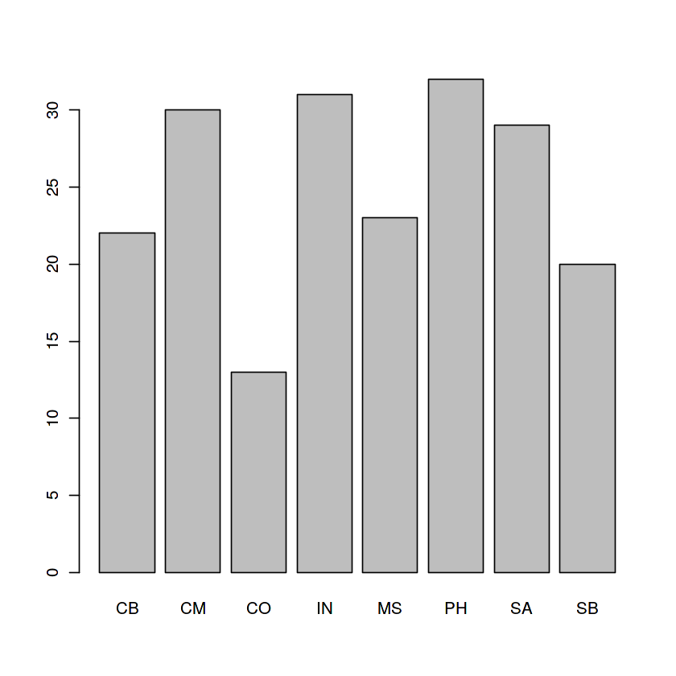

```r
windows(); barplot(height = table(prof$Dep))
```

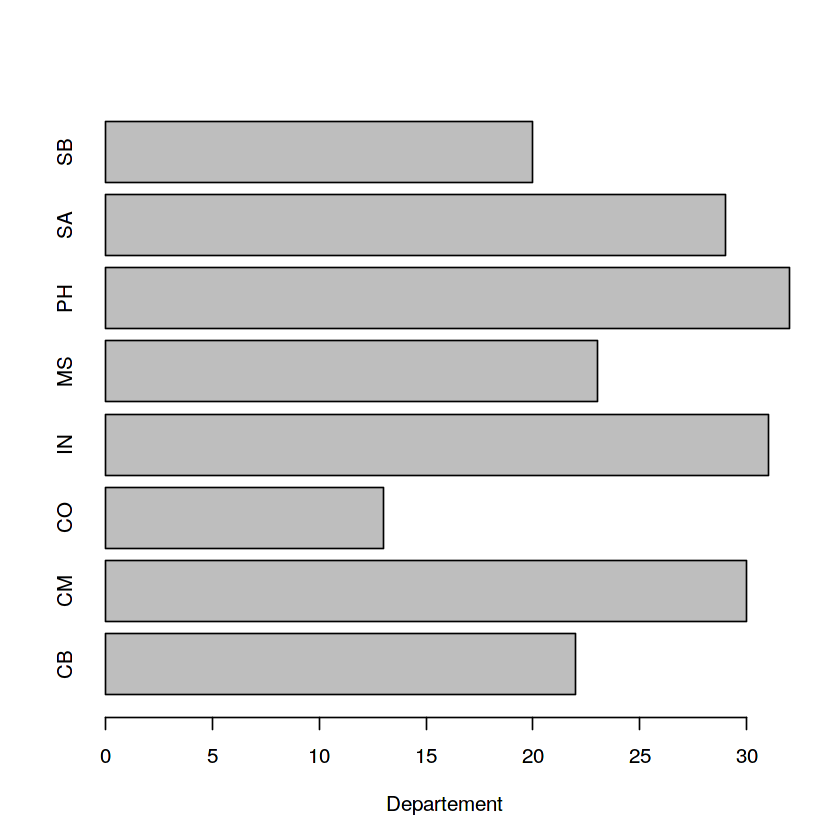

```r
barplot(height=table(prof$Dep),horiz=TRUE,xlab="Departement")
```

Avec le prochain test, ca me donne kkchose et la probabilite critique, il faut que p-value soit plus petite que 0.05 pour que H0 soit rejeté.

```r
chisq.test(table(prof$Dep))
```

```
	Chi-squared test for given probabilities

data:  table(prof$Dep)
X-squared = 12.32, df = 7, p-value = 0.09051
```

Par exemple, ici notre p-value = 0.09052 > 0.05, donc on ne peut pas rejeté.

Plein de statistiques de bases (dans un vecteur):

```r
Sal01 = prof$Sal01
c(mean(Sal01),sd(Sal01),median(Sal01),min(Sal01),max(Sal01),quantile(Sal01))
```

**1**

49034.905

**2**

9485.52718756873

**3**

51646

**4**

27561

**5**

66220

**0%**

27561

**25%**

41859.5

**50%**

51646

**75%**

56037

**100%**

66220

Les fonctions, on peut faire des scriptR de fonctions ou simplement les laisser dans le script de base, il est important de les exécuter avant de les utiliser, vu que je suis dans jupyter, je les mets ici:

```r
#exemple de fonction on l'appelle stats
stats = function(x) {
	sdb = c(mean(x), sd(x), median(x), min(x), max(x))
    names(sdb)= c("Moyenne","Écart-type","Médiane","Minimum","Maximum")
	return(sdb)
}
```

```r
stats(Sal01)
```

**Moyenne**

49034.905

**Écart-type**

9485.52718756873

**Médiane**

51646

**Minimum**

27561

**Maximum**

66220

```r
#une fonction "univariate"

univ = function(x){
	sdb = stats(x)
	p = c(0.01, 0.1, 0.25, 0.50, 0.75, 0.9, 0.95, 0.99)
	Q = quantile(x, probs =p)
	return(list(sdb=sdb, Q=Q))
}
```

```r
univ(Sal01)
```

**$sdb**

**Moyenne**

49034.905

**Écart-type**

9485.52718756873

**Médiane**

51646

**Minimum**

27561

**Maximum**

66220

**$Q**

**1%**

28390

**10%**

34255.8

**25%**

41859.5

**50%**

51646

**75%**

56037

**90%**

59121.6

**95%**

62317

**99%**

65611.22

Maintenant les histogrammes:

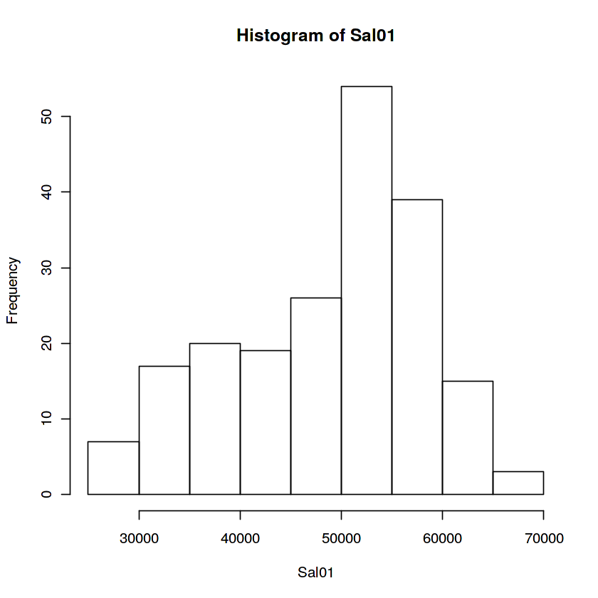

```r
hist(Sal01)
```

Le même histogramme, mais avec un changement de borne et de "casse"

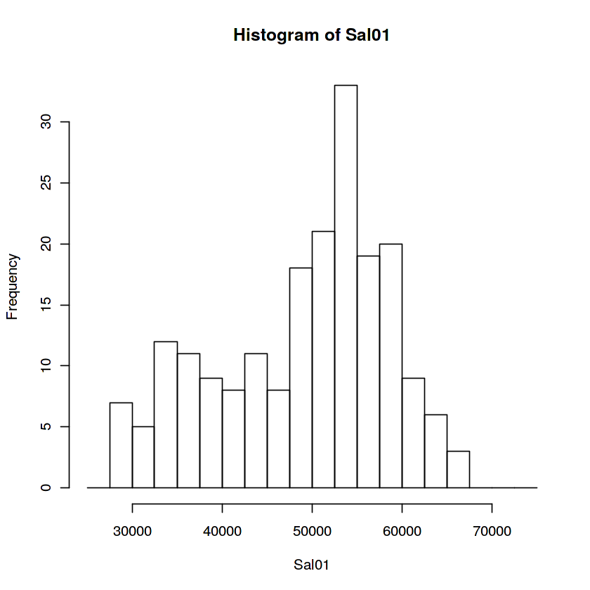

```r
hist(Sal01,breaks = seq(25000, 75000,2500))
```

Le même, mais avec des titres

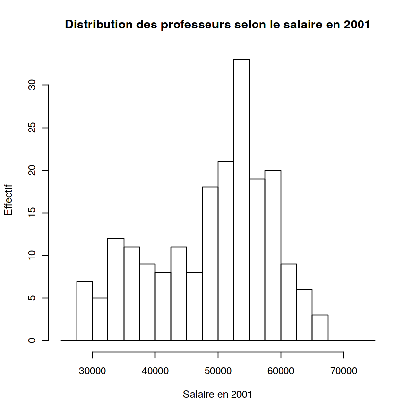

```r
hist(Sal01,breaks = seq(25000, 75000,2500), xlab="Salaire en 2001", ylab= "Effectif", main = "Distribution des professeurs selon le salaire en 2001")
```

Un graphique en boite de moustache:

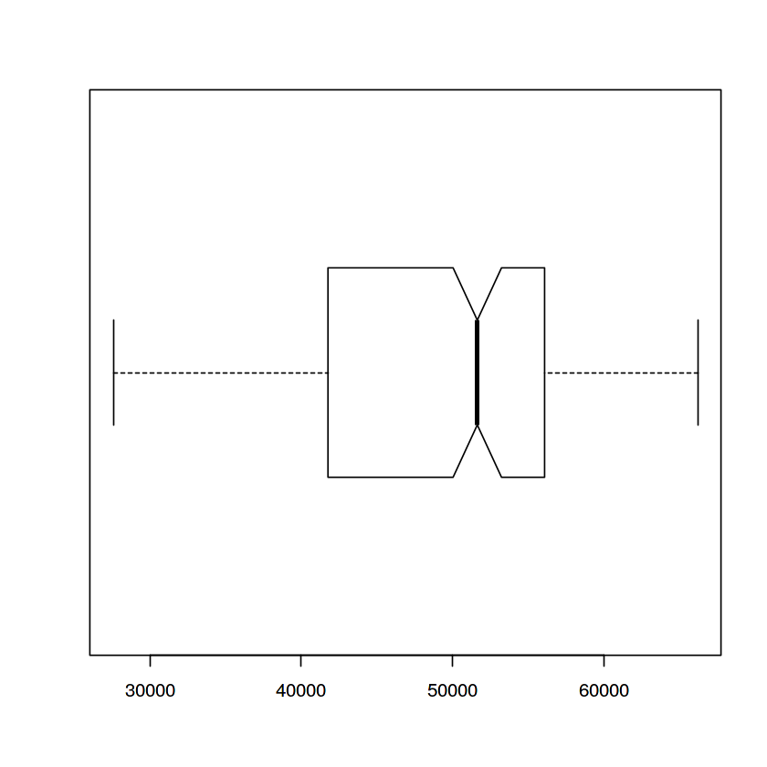

```r
boxplot(x=Sal01, horizontal = TRUE, notch=TRUE)
```

Rappel, toujours mettre windows(); avant les commandes pour le graphique, peu importe le graphique.

Une affaire de la loit normal qqplot

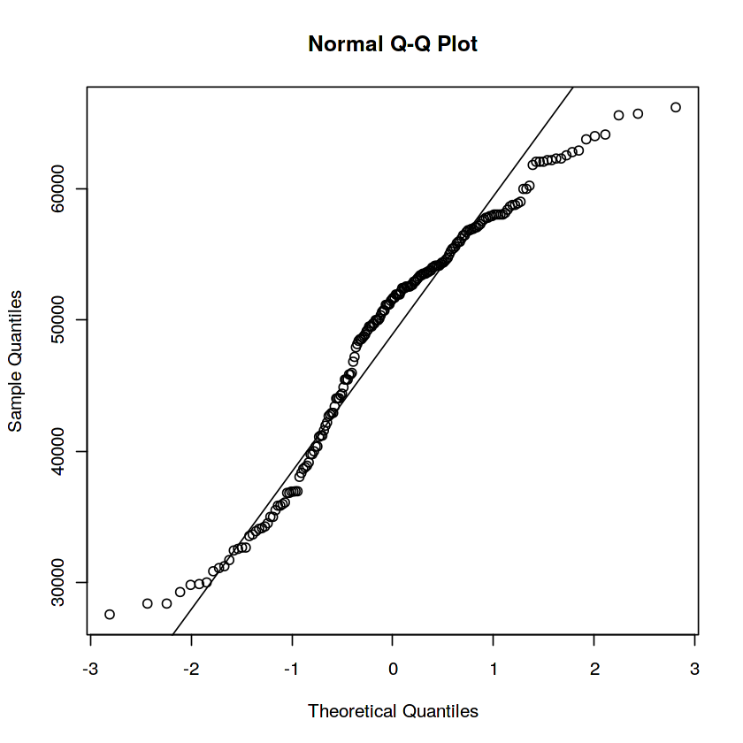

```r
qqnorm(Sal01); qqline(Sal01)
```

Pour 2 variables quantitatives:

```r
salent = prof$SalEnt
cor(salent, Sal01)
```

-0.854731594419724

```r
cor(salent, Sal01, method = "kendall")
```

-0.662203043010985

```r
cor(salent, Sal01, method = "pearson")
```

-0.854731594419724

```r
cor(salent, Sal01, method = "spearman")
```

-0.843104054866144

```r
cor.test(salent, Sal01, method = "spearman")
```

```
	Spearman's rank correlation rho

data:  salent and Sal01
S = 2457400, p-value < 2.2e-16
alternative hypothesis: true rho is not equal to 0
sample estimates:
       rho
-0.8431041
```

```r
exp = prof$Exp
cor.test(salent, exp, method = "spearman")
```

```
	Spearman's rank correlation rho

data:  salent and exp
S = 1192000, p-value = 0.1354
alternative hypothesis: true rho is not equal to 0
sample estimates:
      rho
0.1059575
```

Nuages de points

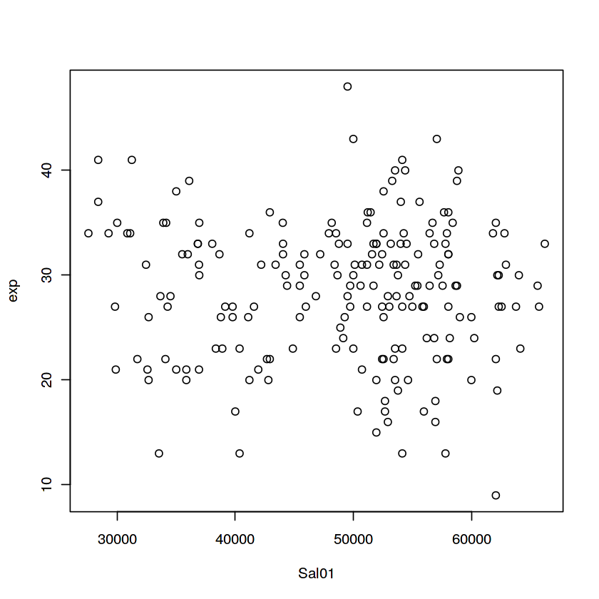

```r
plot(Sal01, exp, type= "p")
```

```r
cor(salent, exp, method = "pearson")
```

0.140753954602053

```r
cor(salent, Sal01, method = "pearson")
```

-0.854731594419724

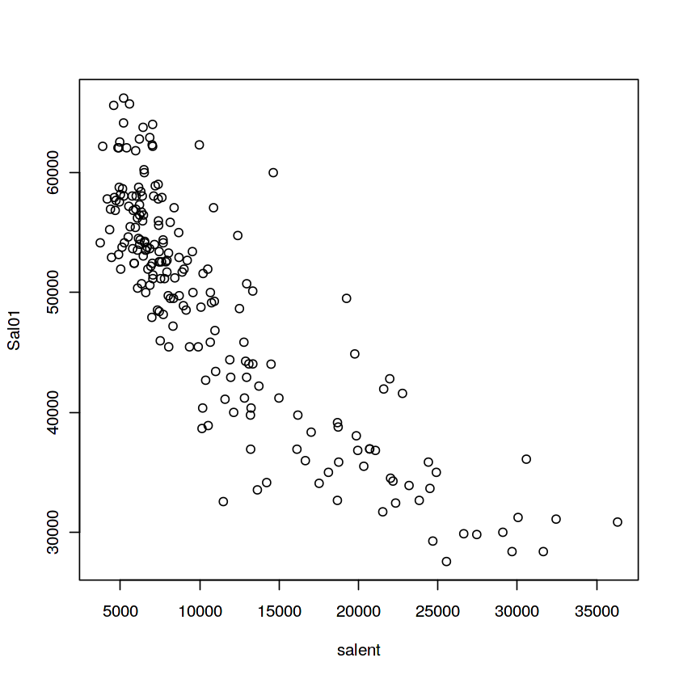

```r
plot(salent, Sal01, type = "p")
```

Bonne chose à faire, savoir interpreter ces graphiques.

variable qualitative: table barplot chisq.test variable quantitative: univ, hist, boxplot, qqnorm; qqline 2 var quantitative: cor, plot, cor.test 2 var qualitative: demain